# Data Storytelling Project: Spatial Patterns in Boston Housing Values

Kieran Hefferan

6/7/26

# 1 Introduction and Motivation

This report completes the visual exploratory analysis template using the **BostonHousing.csv** dataset. The project uses `ggplot()` for static visual design and `ggplotly()` as an interactive wrapper so that points, outliers, and spatial clusters can be inspected directly.

The core practical question is: **Which neighborhood, structural, environmental, accessibility, and spatial factors are associated with median housing value?** The response variable selected for regression is **MEDV**, the median owner-occupied home value in thousands of dollars.

## 1.1 Background Story and Data Generation Process

The dataset contains 506 census traced level observations from the Boston housing data. Each row represents a tract or neighborhood unit, and the columns describe housing value, demographics, environmental exposure, tax/accessibility conditions, and spatial coordinates. The file used in this report is loaded from the working directory as `BostonHousing.csv`.

The original population of interest is housing tracts in and around the Boston metropolitan area. For this data visualization assignment, the analytic goal is not only to describe housing values, but also to determine whether **spatial patterns** help explain or improve later modeling.

```r
df_raw <- read.csv("BostonHousing.csv")

# Initial inspection
list(
  rows = nrow(df_raw),
  columns = ncol(df_raw),
  column_names = names(df_raw)
)
```

```
## $rows
## [1] 506
##
## $columns
## [1] 21
##
## $column_names
##  [1] "X"       "TOWN"    "TOWNNO"  "TRACT"   "LON"     "LAT"     "MEDV"
##  [8] "CMEDV"   "CRIM"    "ZN"      "INDUS"   "CHAS"    "NOX"     "RM"
## [15] "AGE"     "DIS"     "RAD"     "TAX"     "PTRATIO" "B"       "LSTAT"
```

## 1.2 Data Dictionary

```r
data_dictionary <- tribble(
  ~Variable_Name, ~Description, ~Variable_Type,
  "TOWN", "Town or Boston neighborhood name", "Categorical",
  "TRACT", "Census tract identifier", "Identifier",
  "LON", "Longitude coordinate", "Spatial numeric",
  "LAT", "Latitude coordinate", "Spatial numeric",
  "MEDV", "Median value of owner-occupied homes, in $1,000s", "Numeric response",
  "CMEDV", "Corrected median home value, in $1,000s", "Numeric",
  "CRIM", "Per-capita crime rate", "Numeric",
  "ZN", "Proportion of residential land zoned for large lots", "Numeric",
  "INDUS", "Proportion of non-retail business acres", "Numeric",
  "CHAS", "Charles River dummy variable: 1 if tract bounds river, 0 otherwise", "Binary categorical",
  "NOX", "Nitric oxide concentration", "Numeric",
  "RM", "Average number of rooms per dwelling", "Numeric",
  "AGE", "Proportion of owner-occupied units built before 1940", "Numeric",
  "DIS", "Weighted distance to employment centers", "Numeric",
  "RAD", "Accessibility index to radial highways", "Numeric/integer",
  "TAX", "Full-value property-tax rate", "Numeric",
  "PTRATIO", "Pupil-teacher ratio", "Numeric",
  "B", "Demographic index from the original housing dataset", "Numeric",
  "LSTAT", "Percent lower-status population", "Numeric"
)

datatable(data_dictionary, caption = "Table 1: Data dictionary", rownames = FALSE,
          options = list(pageLength = 10, dom = 'tip'))
```

| Variable_Name | Description | Variable_Type |
| --- | --- | --- |
| TOWN | Town or Boston neighborhood name | Categorical |
| TRACT | Census tract identifier | Identifier |
| LON | Longitude coordinate | Spatial numeric |
| LAT | Latitude coordinate | Spatial numeric |
| MEDV | Median value of owner-occupied homes, in $1,000s | Numeric response |
| CMEDV | Corrected median home value, in $1,000s | Numeric |
| CRIM | Per-capita crime rate | Numeric |
| ZN | Proportion of residential land zoned for large lots | Numeric |
| INDUS | Proportion of non-retail business acres | Numeric |
| CHAS | Charles River dummy variable: 1 if tract bounds river, 0 otherwise | Binary categorical |

[output cut: 9 more lines]

## 1.3 Business Questions and Hypotheses

**Business Question 1:** What tract characteristics are most strongly associated with median housing value?

**Business Question 2:** Do spatial patterns in longitude and latitude reveal neighborhoods or clusters with systematically higher or lower home values?

**Business Question 3:** Can spatial findings be turned into useful engineered variables for later regression analysis?

**H1:** Tracts with more rooms (`RM`) have higher median housing values.

**H2:** Tracts with higher lower-status population share (`LSTAT`), higher pollution (`NOX`), higher crime (`CRIM`), and higher pupil-teacher ratios (`PTRATIO`) have lower median housing values.

**H3:** Spatial position matters: tracts in different coordinate bands and town clusters display different price levels, making spatial features useful for feature engineering.

# 2 Visual Exploratory Analytic Plan

The visual EDA follows four phases. First, inspect the dataset for missing values, impossible values, and suspicious spatial coordinates. Second, examine distributions of key numeric and categorical variables. Third, study relationships between spatial and non-spatial variables using interactive scatterplots and grouped comparisons. Fourth, create an analytic dataset and fit a regression model for `MEDV`.

# 3 Data Inspection and Analytic Dataset Construction

## 3.1 Missing Values and Basic Structure

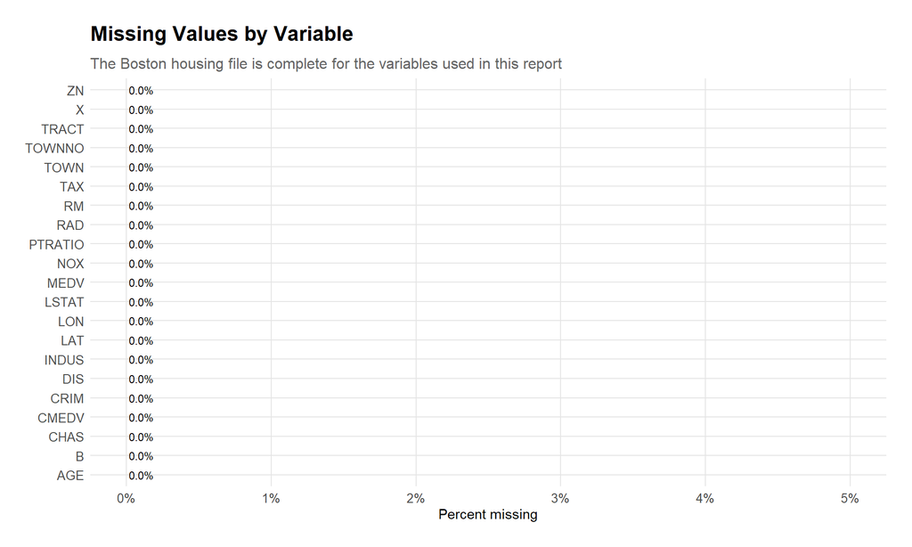

```r
missing_summary <- df_raw %>%
  summarise(across(everything(), ~ sum(is.na(.)))) %>%
  pivot_longer(everything(), names_to = "variable", values_to = "missing_count") %>%
  mutate(pct_missing = missing_count / nrow(df_raw)) %>%
  arrange(desc(missing_count))

p_missing <- ggplot(missing_summary, aes(x = reorder(variable, pct_missing), y = pct_missing)) +
  geom_col(alpha = 0.85) +
  geom_text(aes(label = percent(pct_missing, accuracy = 0.1)), hjust = -0.1, size = 3) +
  coord_flip() +
  scale_y_continuous(labels = percent, limits = c(0, max(missing_summary$pct_missing) + 0.05)) +
  labs(
    title = "Missing Values by Variable",
    subtitle = "The Boston housing file is complete for the variables used in this report",
    x = NULL,
    y = "Percent missing"
  ) +
  theme_storytelling

p_missing
```

```r
ggplotly(p_missing)
```

[interactive chart not shown]

**Observation:** The Boston housing dataset has no missing values in the file. No imputation is needed. The key data-quality concern is not missingness, but suspicious spatial coordinates, which are inspected below.

## 3.2 Spatial Coordinate Quality Check

Because this project includes spatial analysis, longitude and latitude must be checked before mapping. Massachusetts/Boston-area coordinates should be roughly near longitude -73 to -69 and latitude 41 to 43. Some town names in the file share names with towns in other states, creating suspicious geocoding outliers.

```r
df_checked <- df_raw %>%
  mutate(
    coordinate_status = if_else(LON >= -73 & LON <= -69 & LAT >= 41 & LAT <= 43,
                                "Valid Boston-area coordinate",
                                "Suspicious coordinate"),
    value_segment = ntile(MEDV, 4),
    value_segment = factor(value_segment,
                           levels = 1:4,
                           labels = c("Low", "Mid-low", "Mid-high", "High")),
    log_crim = log1p(CRIM),
    log_tax = log1p(TAX),
    high_value = if_else(MEDV >= quantile(MEDV, 0.75), 1, 0)
  )

coord_summary <- df_checked %>%
  count(coordinate_status) %>%
  mutate(pct = n / sum(n))

kable(coord_summary, digits = 3, caption = "Coordinate quality summary")
```

Coordinate quality summary

| coordinate_status | n | pct |
| --- | --- | --- |
| Suspicious coordinate | 77 | 0.152 |
| Valid Boston-area coordinate | 429 | 0.848 |

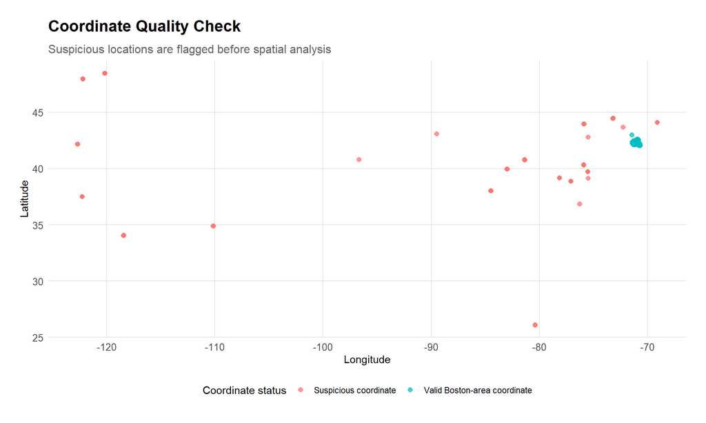

```r
p_coord <- ggplot(df_checked, aes(x = LON, y = LAT, color = coordinate_status,
                                  text = paste("Town:", TOWN,
                                               "<br>MEDV:", MEDV,
                                               "<br>Tract:", TRACT))) +
  geom_point(alpha = 0.75, size = 2) +
  labs(
    title = "Coordinate Quality Check",
    subtitle = "Suspicious locations are flagged before spatial analysis",
    x = "Longitude",
    y = "Latitude",
    color = "Coordinate status"
  ) +
  theme_storytelling

p_coord
```

```r
ggplotly(p_coord, tooltip = "text")
```

[interactive chart not shown]

## 3.3 Create the Analytic Dataset

The analytic dataset keeps all non-spatial variables, creates transformations for skewed variables, flags high-value tracts, and uses only valid Boston-area coordinates for spatial features.

```r
valid_spatial <- df_checked %>%
  filter(coordinate_status == "Valid Boston-area coordinate") %>%
  mutate(
    # Approximate Boston city-center reference point for relative spatial distance.
    dist_boston_core = sqrt((LON - (-71.057))^2 + (LAT - 42.360)^2),
    north_south = if_else(LAT >= median(LAT), "Northern tracts", "Southern tracts"),
    east_west = if_else(LON >= median(LON), "Eastern tracts", "Western tracts"),
    spatial_zone = paste(north_south, east_west, sep = " / ")
  )

analytic_df <- valid_spatial %>%
  select(TOWN, TRACT, LON, LAT, MEDV, CMEDV, CRIM, log_crim, ZN, INDUS, CHAS,
         NOX, RM, AGE, DIS, RAD, TAX, log_tax, PTRATIO, B, LSTAT,
         value_segment, high_value, dist_boston_core, north_south, east_west, spatial_zone)

glimpse(analytic_df)
```

```
## Rows: 429
## Columns: 27
## $ TOWN             <chr> "Bedford", "Bedford", "Beverly", "Beverly", "Beverly"…
## $ TRACT            <int> 3591, 3593, 2173, 2174, 2175, 2176, 2172, 2171, 3, 4,…
## $ LON              <dbl> -71.27061, -71.28141, -70.89063, -70.89213, -70.88213…
## $ LAT              <dbl> 42.48912, 42.49212, 42.56884, 42.55484, 42.55984, 42.…
## $ MEDV             <dbl> 31.1, 29.1, 18.7, 16.0, 22.2, 25.0, 19.6, 23.3, 22.7,…
## $ CMEDV            <dbl> 31.1, 29.1, 18.7, 16.0, 22.2, 25.0, 19.6, 23.3, 22.7,…
## $ CRIM             <dbl> 0.02187, 0.01439, 0.14932, 0.17171, 0.11027, 0.12650,…
## $ log_crim         <dbl> 0.02163428, 0.01428745, 0.13917046, 0.15846422, 0.104…
## $ ZN               <dbl> 60, 60, 25, 25, 25, 25, 25, 25, 0, 0, 0, 0, 0, 0, 0, …
## $ INDUS            <dbl> 2.93, 2.93, 5.13, 5.13, 5.13, 5.13, 5.13, 5.13, 18.10…
## $ CHAS             <int> 0, 0, 0, 0, 0, 0, 0, 0, 1, 0, 0, 1, 1, 0, 1, 0, 0, 0,…
## $ NOX              <dbl> 0.401, 0.401, 0.453, 0.453, 0.453, 0.453, 0.453, 0.45…
## $ RM               <dbl> 6.800, 6.604, 5.741, 5.966, 6.456, 6.762, 5.927, 6.14…
## $ AGE              <dbl> 9.9, 18.8, 66.2, 93.4, 67.8, 43.4, 47.2, 29.2, 83.4, …
## $ DIS              <dbl> 6.2196, 6.2196, 7.2254, 6.8185, 7.2255, 7.9809, 6.932…
## $ RAD              <int> 1, 1, 8, 8, 8, 8, 8, 8, 24, 24, 24, 24, 24, 24, 24, 2…
## $ TAX              <int> 265, 265, 284, 284, 284, 284, 284, 284, 666, 666, 666…
## $ log_tax          <dbl> 5.583496, 5.583496, 5.652489, 5.652489, 5.652489, 5.6…
## $ PTRATIO          <dbl> 15.6, 15.6, 19.7, 19.7, 19.7, 19.7, 19.7, 19.7, 20.2,…
## $ B                <dbl> 393.37, 376.70, 395.11, 378.08, 396.90, 395.58, 396.9…
## $ LSTAT            <dbl> 5.03, 4.38, 13.15, 14.44, 6.73, 9.50, 9.22, 6.86, 11.…
## $ value_segment    <fct> High, High, Mid-low, Low, Mid-high, Mid-high, Mid-low…
## $ high_value       <dbl> 1, 1, 0, 0, 0, 1, 0, 0, 0, 0, 1, 0, 0, 0, 0, 0, 1, 1,…
## $ dist_boston_core <dbl> 0.24960276, 0.26041480, 0.26701015, 0.25523697, 0.265…
## $ north_south      <chr> "Northern tracts", "Northern tracts", "Northern tract…
## $ east_west        <chr> "Western tracts", "Western tracts", "Eastern tracts",…
## $ spatial_zone     <chr> "Northern tracts / Western tracts", "Northern tracts …
```

# 4 Distributional Patterns of Individual Variables

## 4.1 Numeric Variable Distributions

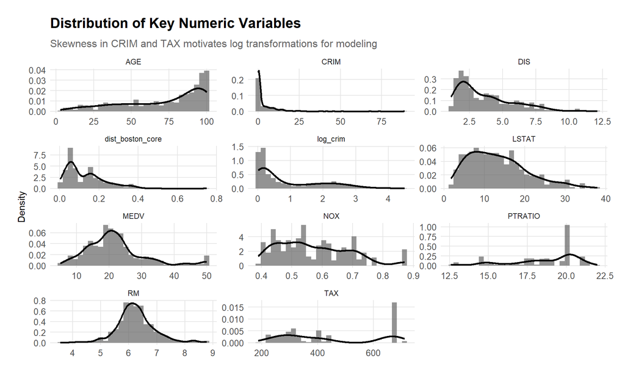

```r
key_numeric <- analytic_df %>%
  select(MEDV, CRIM, log_crim, RM, LSTAT, NOX, DIS, TAX, PTRATIO, AGE, dist_boston_core)

numeric_long <- key_numeric %>%
  pivot_longer(everything(), names_to = "variable", values_to = "value")

p_numeric <- ggplot(numeric_long, aes(x = value)) +
  geom_histogram(aes(y = after_stat(density)), bins = 30, alpha = 0.65) +
  geom_density(linewidth = 1) +
  facet_wrap(~ variable, scales = "free", ncol = 3) +
  labs(
    title = "Distribution of Key Numeric Variables",
    subtitle = "Skewness in CRIM and TAX motivates log transformations for modeling",
    x = NULL,
    y = "Density"
  ) +
  theme_storytelling

p_numeric
```

```r
ggplotly(p_numeric)
```

[interactive chart not shown]

**Observation:** `MEDV` is right-skewed and capped at 50 for the highest-value tracts. `CRIM` is highly right-skewed, so `log_crim` is created. `LSTAT` and `PTRATIO` vary meaningfully across tracts and are expected to be strong predictors of housing value.

## 4.2 Categorical and Engineered Group Distributions

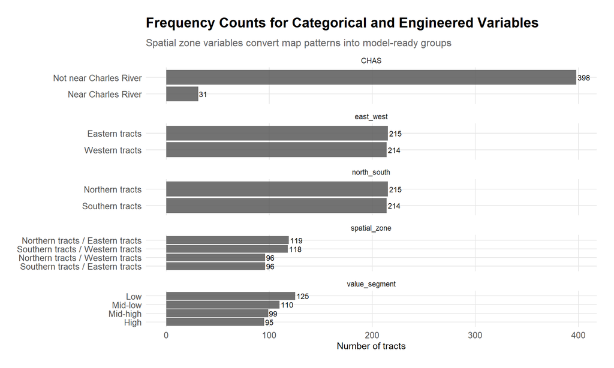

```r
cat_long <- analytic_df %>%
  select(CHAS, value_segment, north_south, east_west, spatial_zone) %>%
  mutate(CHAS = factor(CHAS, labels = c("Not near Charles River", "Near Charles River"))) %>%
  pivot_longer(everything(), names_to = "variable", values_to = "category")

p_cat <- ggplot(cat_long, aes(y = fct_rev(fct_infreq(category)))) +
  geom_bar(alpha = 0.85) +
  geom_text(stat = "count", aes(label = after_stat(count)), hjust = -0.1, size = 3) +
  facet_wrap(~ variable, scales = "free_y", ncol = 1) +
  labs(
    title = "Frequency Counts for Categorical and Engineered Variables",
    subtitle = "Spatial zone variables convert map patterns into model-ready groups",
    x = "Number of tracts",
    y = NULL
  ) +
  theme_storytelling

p_cat
```

```r
ggplotly(p_cat)
```

[interactive chart not shown]

# 5 Spatial Patterns and Relationships

## 5.1 Spatial Pattern in Housing Values

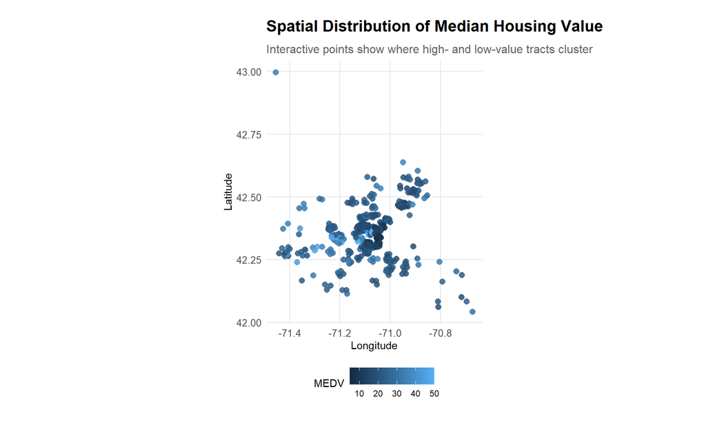

```r
p_map_medv <- ggplot(analytic_df, aes(x = LON, y = LAT, color = MEDV,
                                      text = paste("Town:", TOWN,
                                                   "<br>MEDV:", MEDV,
                                                   "<br>RM:", RM,
                                                   "<br>LSTAT:", LSTAT))) +
  geom_point(alpha = 0.85, size = 2.5) +
  coord_equal() +
  labs(
    title = "Spatial Distribution of Median Housing Value",
    subtitle = "Interactive points show where high- and low-value tracts cluster",
    x = "Longitude",
    y = "Latitude",
    color = "MEDV"
  ) +
  theme_storytelling

p_map_medv
```

```r
ggplotly(p_map_medv, tooltip = "text")
```

[interactive chart not shown]

**Spatial interpretation:** Housing values are not randomly scattered across space. Higher-value tracts tend to cluster in specific spatial areas, while lower-value tracts cluster in other town/neighborhood bands. This supports using spatially derived features rather than treating longitude and latitude only as raw coordinates.

## 5.2 Relationship Between Spatial and Non-Spatial Variables

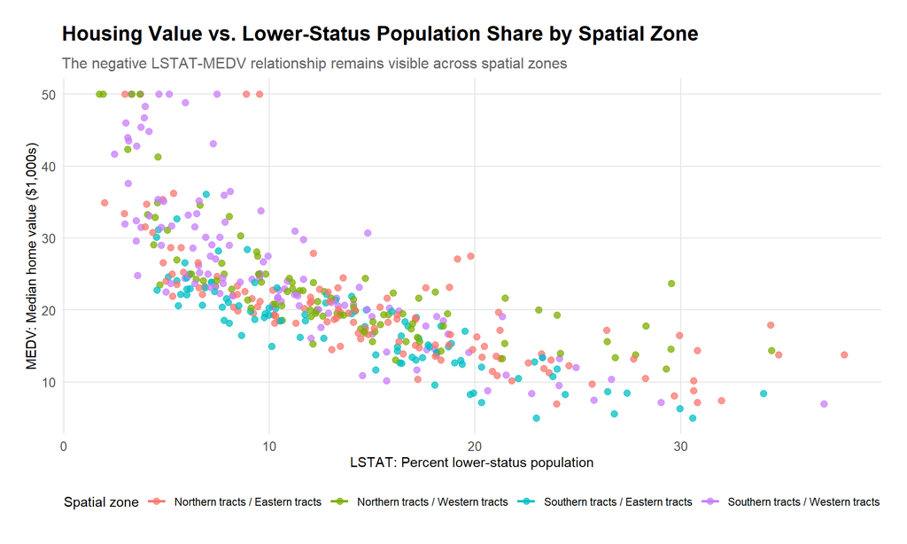

```r
p_spatial_lstat <- ggplot(analytic_df, aes(x = LSTAT, y = MEDV, color = spatial_zone,
                                           text = paste("Town:", TOWN,
                                                        "<br>Spatial zone:", spatial_zone,
                                                        "<br>LSTAT:", LSTAT,
                                                        "<br>MEDV:", MEDV))) +
  geom_point(alpha = 0.75, size = 2.3) +
  geom_smooth(method = "lm", se = FALSE) +
  labs(
    title = "Housing Value vs. Lower-Status Population Share by Spatial Zone",
    subtitle = "The negative LSTAT-MEDV relationship remains visible across spatial zones",
    x = "LSTAT: Percent lower-status population",
    y = "MEDV: Median home value ($1,000s)",
    color = "Spatial zone"
  ) +
  theme_storytelling

p_spatial_lstat
```

```r
ggplotly(p_spatial_lstat, tooltip = "text")
```

[interactive chart not shown]

**Observation:** `LSTAT` has a strong negative relationship with `MEDV`. The color grouping shows that spatial zones have different mixes of socioeconomic conditions and housing values, which means spatial context can help explain patterns that are not visible from a single predictor alone.

## 5.3 Grouped Spatial Comparisons

[figure not shown]

```r
p_zone <- ggplot(analytic_df, aes(x = spatial_zone, y = MEDV, fill = spatial_zone,
                                  text = paste("Spatial zone:", spatial_zone,
                                               "<br>MEDV:", MEDV))) +
  geom_violin(trim = FALSE, alpha = 0.6) +
  geom_boxplot(width = 0.15, alpha = 0.85, outlier.alpha = 0.4) +
  labs(
    title = "Distribution of Housing Values by Engineered Spatial Zone",
    subtitle = "Spatial grouping reveals different price distributions across coordinate bands",
    x = "Engineered spatial zone",
    y = "MEDV: Median home value ($1,000s)"
  ) +
  theme_storytelling +
  theme(axis.text.x = element_text(angle = 25, hjust = 1), legend.position = "none")

p_zone
```

```r
ggplotly(p_zone, tooltip = "text")
```

[interactive chart not shown]

**Feature-engineering conclusion:** Spatial patterns help define useful new variables: `north_south`, `east_west`, `spatial_zone`, and `dist_boston_core`. These variables summarize location in a model-friendly way and avoid overfitting raw longitude/latitude.

# 6 Relationship Analysis Between Predictors and Response

## 6.1 Correlation Analysis

```r
cor_df <- analytic_df %>%
  select(MEDV, RM, LSTAT, CRIM, log_crim, NOX, AGE, DIS, RAD, TAX, log_tax, PTRATIO, dist_boston_core) %>%
  cor(use = "complete.obs") %>%
  as.data.frame() %>%
  rownames_to_column("variable") %>%
  select(variable, MEDV) %>%
  arrange(desc(abs(MEDV)))

kable(cor_df, digits = 3, caption = "Correlation of numeric predictors with MEDV")
```

Correlation of numeric predictors with MEDV

| variable | MEDV |
| --- | --- |
| MEDV | 1.000 |
| LSTAT | -0.743 |
| RM | 0.659 |
| PTRATIO | -0.491 |
| log_tax | -0.469 |
| log_crim | -0.464 |
| TAX | -0.463 |
| NOX | -0.407 |
| CRIM | -0.395 |
| RAD | -0.376 |
| AGE | -0.370 |
| dist_boston_core | 0.321 |
| DIS | 0.272 |

The strongest expected relationships are positive for `RM` and negative for `LSTAT`, `PTRATIO`, `TAX`, `NOX`, and `CRIM`. Distance and spatial group variables are weaker on their own, but they are still useful because they summarize local geography.

## 6.2 Key Bivariate Relationships

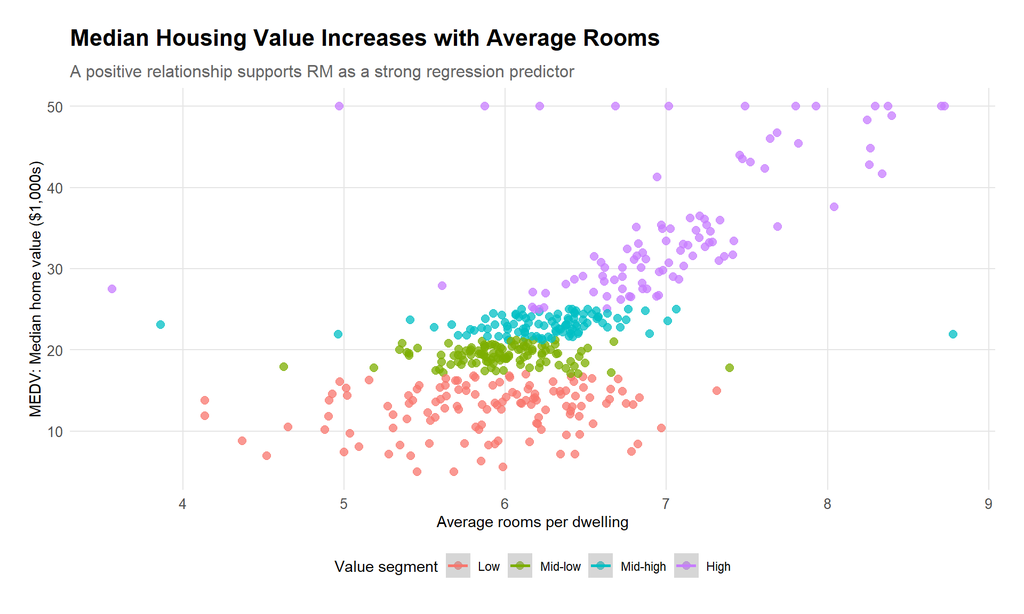

```r
p_rm <- ggplot(analytic_df, aes(x = RM, y = MEDV, color = value_segment,
                                text = paste("Town:", TOWN,
                                             "<br>RM:", RM,
                                             "<br>MEDV:", MEDV))) +
  geom_point(alpha = 0.75, size = 2.4) +
  geom_smooth(method = "loess", se = TRUE) +
  labs(
    title = "Median Housing Value Increases with Average Rooms",
    subtitle = "A positive relationship supports RM as a strong regression predictor",
    x = "Average rooms per dwelling",
    y = "MEDV: Median home value ($1,000s)",
    color = "Value segment"
  ) +
  theme_storytelling

p_rm
```

```r
ggplotly(p_rm, tooltip = "text")
```

[interactive chart not shown]

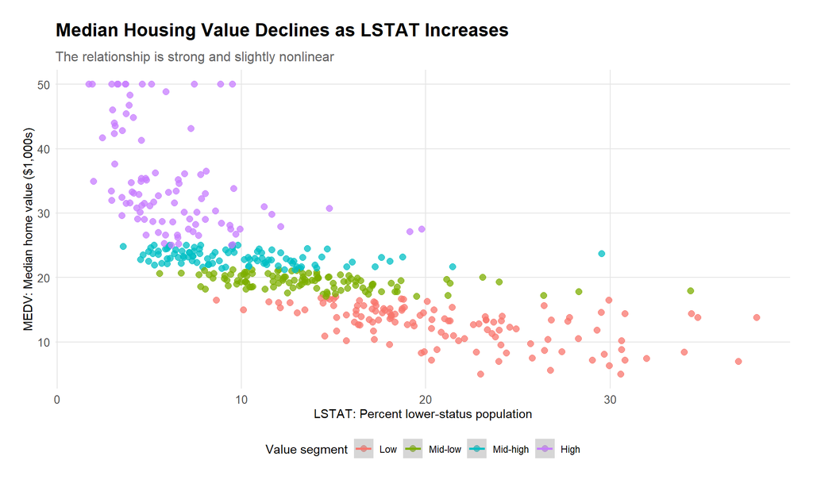

```r
p_lstat <- ggplot(analytic_df, aes(x = LSTAT, y = MEDV, color = value_segment,
                                   text = paste("Town:", TOWN,
                                                "<br>LSTAT:", LSTAT,
                                                "<br>MEDV:", MEDV))) +
  geom_point(alpha = 0.75, size = 2.4) +
  geom_smooth(method = "loess", se = TRUE) +
  labs(
    title = "Median Housing Value Declines as LSTAT Increases",
    subtitle = "The relationship is strong and slightly nonlinear",
    x = "LSTAT: Percent lower-status population",
    y = "MEDV: Median home value ($1,000s)",
    color = "Value segment"
  ) +
  theme_storytelling

p_lstat
```

```r
ggplotly(p_lstat, tooltip = "text")
```

[interactive chart not shown]

# 7 Regression Analysis

## 7.1 Response Variable Selection

The response variable is **MEDV**, median owner-occupied home value in thousands of dollars. This is practically meaningful because it represents neighborhood housing affordability and market value. The regression model estimates which tract characteristics are associated with higher or lower housing values.

## 7.2 Model Fitting

```r
model_medv <- lm(
  MEDV ~ RM + LSTAT + log_crim + PTRATIO + NOX + DIS + CHAS +
    RAD + log_tax + dist_boston_core + spatial_zone,
  data = analytic_df
)

model_summary <- glance(model_medv)
coef_table <- tidy(model_medv, conf.int = TRUE) %>%
  mutate(across(where(is.numeric), ~ round(.x, 4)))

kable(model_summary %>% select(r.squared, adj.r.squared, sigma, statistic, p.value, AIC, BIC),
      digits = 4, caption = "Regression model fit summary")
```

Regression model fit summary

| r.squared | adj.r.squared | sigma | statistic | p.value | AIC | BIC |
| --- | --- | --- | --- | --- | --- | --- |
| 0.7228 | 0.7141 | 4.8373 | 83.2527 | 0 | 2585.736 | 2646.657 |

```r
kable(coef_table, caption = "Regression coefficient table")
```

Regression coefficient table

| term | estimate | std.error | statistic | p.value | conf.low | conf.high |
| --- | --- | --- | --- | --- | --- | --- |
| (Intercept) | 61.5393 | 9.5707 | 6.4300 | 0.0000 | 42.7263 | 80.3524 |
| RM | 3.2492 | 0.4398 | 7.3883 | 0.0000 | 2.3847 | 4.1137 |
| LSTAT | -0.6180 | 0.0519 | -11.9152 | 0.0000 | -0.7199 | -0.5160 |
| log_crim | -1.4161 | 0.6131 | -2.3097 | 0.0214 | -2.6212 | -0.2109 |
| PTRATIO | -0.9553 | 0.1446 | -6.6070 | 0.0000 | -1.2395 | -0.6711 |
| NOX | -11.6704 | 4.1044 | -2.8434 | 0.0047 | -19.7383 | -3.6025 |
| DIS | -1.6881 | 0.4292 | -3.9328 | 0.0001 | -2.5319 | -0.8444 |
| CHAS | 2.5021 | 0.9554 | 2.6189 | 0.0091 | 0.6241 | 4.3801 |
| RAD | 0.3586 | 0.0871 | 4.1190 | 0.0000 | 0.1875 | 0.5298 |
| log_tax | -4.1867 | 1.4979 | -2.7950 | 0.0054 | -7.1311 | -1.2423 |
| dist_boston_core | 16.4505 | 8.3922 | 1.9602 | 0.0506 | -0.0461 | 32.9470 |
| spatial_zoneNorthern tracts / Western tracts | -0.0186 | 0.7881 | -0.0236 | 0.9811 | -1.5677 | 1.5305 |
| spatial_zoneSouthern tracts / Eastern tracts | -2.9825 | 0.7203 | -4.1409 | 0.0000 | -4.3983 | -1.5667 |
| spatial_zoneSouthern tracts / Western tracts | -1.2256 | 0.7668 | -1.5984 | 0.1107 | -2.7328 | 0.2817 |

## 7.3 Coefficient Visualization

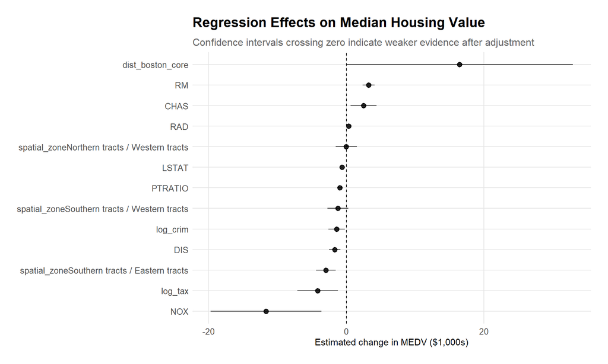

```r
coef_plot_data <- tidy(model_medv, conf.int = TRUE) %>%
  filter(term != "(Intercept)") %>%
  mutate(term = fct_reorder(term, estimate))

p_coef <- ggplot(coef_plot_data, aes(x = estimate, y = term,
                                     text = paste("Predictor:", term,
                                                  "<br>Estimate:", round(estimate, 3),
                                                  "<br>p-value:", round(p.value, 4)))) +
  geom_vline(xintercept = 0, linetype = "dashed") +
  geom_pointrange(aes(xmin = conf.low, xmax = conf.high), alpha = 0.85) +
  labs(
    title = "Regression Effects on Median Housing Value",
    subtitle = "Confidence intervals crossing zero indicate weaker evidence after adjustment",
    x = "Estimated change in MEDV ($1,000s)",
    y = NULL
  ) +
  theme_storytelling

p_coef
```

```r
ggplotly(p_coef, tooltip = "text")
```

[interactive chart not shown]

## 7.4 Regression Diagnostics

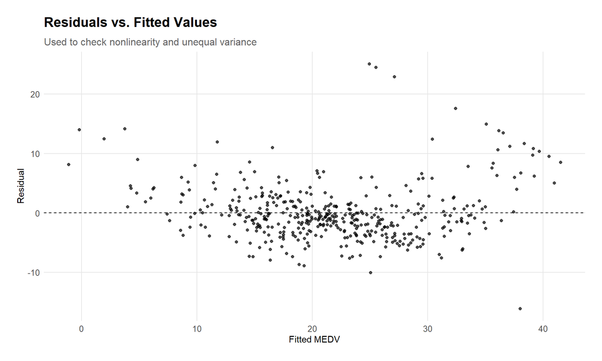

```r
diag_df <- augment(model_medv)

p_resid <- ggplot(diag_df, aes(x = .fitted, y = .resid,
                               text = paste("Fitted:", round(.fitted, 2),
                                            "<br>Residual:", round(.resid, 2)))) +
  geom_point(alpha = 0.7) +
  geom_hline(yintercept = 0, linetype = "dashed") +
  geom_smooth(method = "loess", se = FALSE) +
  labs(
    title = "Residuals vs. Fitted Values",
    subtitle = "Used to check nonlinearity and unequal variance",
    x = "Fitted MEDV",
    y = "Residual"
  ) +
  theme_storytelling

p_resid
```

```r
ggplotly(p_resid, tooltip = "text")
```

[interactive chart not shown]

**Regression interpretation:** The expected model pattern is that `RM` has a positive association with `MEDV`, while `LSTAT`, `PTRATIO`, `NOX`, crime, and tax burden tend to have negative associations. Spatial features should be interpreted as contextual controls. If spatial-zone coefficients remain meaningful after adding socioeconomic and structural variables, then location contributes additional explanatory value beyond the usual housing predictors.

# 8 Effective Visual Storytelling: From Insights to Action

## 8.1 Key Findings

1. The dataset does not require missing-value imputation, but it does require a spatial coordinate quality check.
2. Median housing value is spatially clustered, so mapping is useful for understanding the data.
3. `RM` and `LSTAT` are the clearest bivariate predictors of `MEDV`.
4. Skewed variables such as `CRIM` and `TAX` are better represented with log transformations.
5. Spatial patterns support engineering `spatial_zone` and `dist_boston_core` for subsequent modeling.

## 8.2 Modeling Implications

The analytic dataset is now suitable for later regression, model comparison, or prediction. A useful next step would be to compare the current linear model with a model that excludes spatial features. If the spatial model improves adjusted R-squared, AIC, BIC, or prediction error, then spatial patterns are not only visually interesting but analytically useful.

## 8.3 Practical Recommendation

For housing-market interpretation, analysts should avoid using a single average Boston-area housing value. Housing values vary by structural quality, socioeconomic conditions, environmental exposure, accessibility, and location. A meaningful analysis should combine **non-spatial predictors** with **spatial context**, especially when the goal is to understand neighborhood-level housing-value differences.